# Εργασια 6η

## 4.1 Σχολιασμός τέταρτου ερωτήματος

- Τα είδη (genres) που έχουν μεγάλα ορθογώνια σε κοινές στήλες ή σειρές μπορεί να έχουν παρόμοια χαρακτηριστικά ή να συσχετίζονται μεταξύ τους.
- Εάν ένα είδος (genre) έχει μεγάλο ορθογώνιο (box) στις περισσότερες στήλες, υποδηλώνει ότι αυτό το είδος έχει ισχυρούς συσχετισμούς με πολλά άλλα είδη ή χαρακτηριστικά.
- Αντίθετα, εάν ένα είδος έχει πολύ λίγα ή μικρά ορθογώνια, μπορεί να σημαίνει ότι αυτό το είδος είναι αρκετά διαφορετικό από άλλα ή δεν έχει κοινά χαρακτηριστικά.
- Παράδειγμα αποτελεί το μεγάλο κουτί (box) για τη μεταβλητή - είδος blues. Αυτο συμβαίνει δίοτι τα δύο πεδία (genre 1 and genre 2 ) έχουν την ίδια τιμή, η οποία ορίστηκε σύμφωνα με την εκφώνηση, για τα αλμπουμ που κατατάσσονται σε ένα μόνο είδος.

# 5 5. choropleth map

[output not shown]

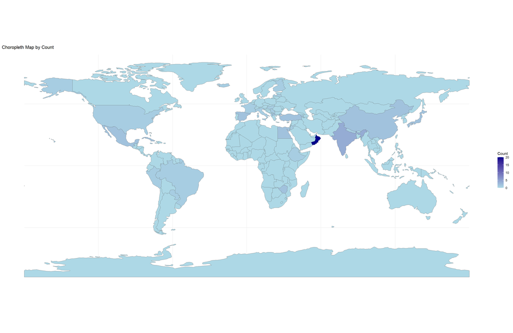

## 5.1 Σχολιασμός πέμπτου ερωτήματος

- Στην παραπάνω απεικόνιση υπάρχει ενας χωροπληθής χάρτης με τις χώρες του πλανήτη.Η Ομάν εμφανίζεται 20 φορές, αλλά όχι απαραίτητα με την ακριβή μορφή του ονόματός της, αλλά μέσα σε λέξεις που περιέχουν το συνθετικό “oman”. Για παραδειγμα στο αλμπουμ “When a Woman Gets the Blues” , η λέξη oman εμπεριέχεται στη λέξη woman που είναι μέρος του τίτλου του αλμπουμ.
- Ακολουθεί η Ινδία η οποία στις 2 περιπτώσεις εμφανίζεται ως India ενω στις άλλες δύο εμπεριέχεται μέσα σε λέξεις.
- Απο 2 εμφανίσεις έχουν οι χώρες όπως το Μεξικό,Κουβα , Τουρκία , Ισπανία , Κίνα και άλλες

```
                                             Θεσσαλονίκη 20-01-2024

                                         Γεώργιος Δημήτριος Γκολογκίνας

                                    Υπεύθυνος καθηγητής : κ.Γεώργιος Ευαγγελίδης
```